# E. Superba

## E. superba

This document aims to reproduce the example presented in Constable and de la Mare (1996).

```r
library(Grym)
library(ggplot2)
library(dplyr)
library(tidyr)
library(furrr)
set.seed(31)
```

## Model

The `EsuperbaProjection` function returns a function that generates a single set of random projections that differ only in gamma. The projections within each set use a common random selectivity and maturity curves, virign biomass and recruitment series, so within a set the projections only differ by the level of fishing applied. The resulting function takes a single numerical argument that is used to identify the set.

```r
EsuperbaProjection <- function(gamma=c(0,0.1,0.136,0.15,0.2),n.years=20) {

  ## Daily time steps with 8 age classes
  nsteps <- 365   #Time steps
  Ages <- 0:7   #Age classes
  Days <- seq(0,1,length=nsteps+1)    #Cummulative time steps
  h <- 1/nsteps  #Proportion of the year for each time step.

  ## Spawning and monitoring interval
  spawnI <- 121:213  #Time steps that spawning occurs on.
  monitorI <- 92    #Time step of the monitoring interval.

  ## Ages, length at age and weight at age
  ages <- outer(Days,Ages,FUN="+")  #Age at each time step in each age class.
  ls <- vonBertalanffyRAL(ages,t0=0.0,K=0.45,Linf=60,f0=0,f1=93/365)   #Length at each time step in each age class.
  ws <- powerLW(L=ls,a=1,b=3)   #Weight at each time step in each age class.

  ## Constant intra-annual natural mortality
  ms <- matrix(data=1,nrow=nsteps+1,ncol=length(Ages))
  Ms <- ctrapz(fs=ms,h=h)
  Msf <- final(P=Ms)

  ## Within year fishing pattern - season is first 90 days
  fwy <- double(length=nsteps+1) #create vector of 0s the length of time steps
  fwy[31:120] <- 1 #Set the time steps of the fishing season to 1
  fwy <- fwy/trapz(fs=fwy, h=h) #Scale the f in the fishing period to be 1 across the year

  B0logsd <- sqrt(log(1+0.3^2))

  ## This function performs the a projection for each prescibed gamma.
  function(run) {

    ## Length based maturity and selectivity - ramp width is constant
    ## but the midpoint is selected uniformly from a range.
    gs <- rampOgive(x=ls, x50=runif(n=1, min=34, max=40), xrange=12) #Maturity
    ss <- rampOgive(x=ls, x50=runif(n=1, min=38, max=42), xrange=10) #Selectivity

    ## Construct fishing mortalities from season and selectivity
    fs <- fwy*ss #Fishing pattern * selectivity
    Fs <- ctrapz(fs=fs, h=h)
    Fsf <- final(P=Fs)

    ## Uniform natural mortalities
    M <- runif(n=1,min=0.4,max=1.0) #Select mortality from within the range
    MMs <- M*Ms #Natural mortality by timestep

    ## Uniform (log) recruitment std dev.
    sigmaR <- sqrt(log(1+runif(n=1, min=0.4, max=0.6)^2))

    ## Median spawning biomass estimated from 1001 samples
    R <- matrix(data=rlnorm(n=1001*length(Msf),meanlog = -sigmaR^2/2, sdlog=sigmaR),                    nrow = 1001,ncol = length(Msf)) #Recruitment matrix
    ssb0 <- spawningB0S(R,gs,ws,Ms,M,spawn=spawnI)$median #Median Spawning biomass

    ## Stochastic initial age structure in the absence of fishing
    N0 <- ageStructureS(R=rlnorm(n=length(Msf), meanlog = -sigmaR^2/2,
                                 sdlog = sigmaR), Msf=Msf, M=M)

    ## Recruitment series
    Rs <- rlnorm(n=n.years, meanlog = -sigmaR^2/2, sdlog = sigmaR)

    ## Matrix of annual summaries
    n <- (1+n.years)*length(gamma) #Sum number of years for each Gamma
    df <- matrix(data=0, nrow = n, ncol = 12+ncol(ages)) #create matrix of data
    colnames(df) <- c("Year","Gamma","R","N","B","B0","SSN","SSB","SSB0","SSB.Status","Catch","F",paste0("Age.Class.",1:ncol(ages))) #Set Column names

    ## Initial projection assuming no fishing
    pr0 <- project(ws=ws, MMs=MMs,Nref=N0,yield=0)
    pr0$F <- pr0$Y <- 0

    ## Initial biomass in monitoring period + log Normal error
    b0 <- meanStock(P=pr0$B, period=monitorI)
    b0 <- rlnorm(n=1, meanlog = log(b0)-B0logsd^2/2, sdlog = B0logsd)

    k <- 0
    ## Project for each gamma ratio
    for(g in gamma) {
      ## Target catch
      catch <- g*b0

      ## Reset to virgin state
      pr <- pr0
      ssb <- spawningStock(P=pr$B, gs=gs, period=spawnI)

      for(yr in 0:n.years) {

        if(yr > 0) {
          ## Recruitment depletion
          r <- min(1,ssb/(0.2*ssb0))
          ## Project over year
          N0 <- advance(N=pr$N,R=r*Rs[yr]) #roll age classes forward
          pr <- projectC(ws=ws,MMs=MMs,Fs=Fs,fs=fs,Catch=catch,Nref=N0,yield=1,Fmax=1.5) #Yearly projections for known catch.
          #if(pr$F==1.5) return(NULL)
        }
        ssb <- spawningStock(P=pr$B,gs=gs,period=spawnI)

        ## Collate annual summaries
        df[k<-k+1,] <- c(yr,g,initial(pr$N)[1],sum(initial(pr$N)),sum(initial(pr$B)),b0,
                        spawningStock(P=pr$N,gs=gs,period =spawnI) ,ssb, ssb0, ssb/ssb0 , sum(pr$Y) ,pr$F, initial(pr$N))
      }
    }
    data.frame(Run=run,M=M,df)
  }
}
```

## Projection

Calling `EsuperbaProjection` returns a function that generates a single “run” of the simulation

```r
sim <- EsuperbaProjection()
```

The function takes a single argument that is used to label the results. Within a single call to `sim`, a common set of random maturity, selectivity, initial ages and recruitment series are used to make projections for each requested gamma.

```r
df <- sim(1)
head(df)
  Run         M Year Gamma         R        N        B       B0       SSN
1   1 0.6561479    0     0 1.8760769 2.744880 47617.16 68260.06 0.4689561
2   1 0.6561479    1     0 0.4240341 1.840092 48932.21 68260.06 0.5983478
3   1 0.6561479    2     0 1.6601061 2.609831 52339.93 68260.06 0.6029807
4   1 0.6561479    3     0 0.9728241 2.322359 53660.99 68260.06 0.6011445
5   1 0.6561479    4     0 0.4856450 1.685634 56579.28 68260.06 0.6562128
6   1 0.6561479    5     0 0.9315665 1.799240 53252.74 68260.06 0.5271349
       SSB     SSB0 SSB.Status Catch F Age.Class.1 Age.Class.2 Age.Class.3
1 50077.93 52832.71  0.9478584     0 0   1.8760769   0.3786343   0.1710556
2 52647.70 52832.71  0.9964982     0 0   0.4240341   0.9733953   0.1964529
3 60824.31 52832.71  1.1512625     0 0   1.6601061   0.2200084   0.5050424
4 56872.01 52832.71  1.0764545     0 0   0.9728241   0.8613397   0.1141505
5 63885.35 52832.71  1.2092008     0 0   0.4856450   0.5047460   0.4469028
6 57535.90 52832.71  1.0890206     0 0   0.9315665   0.2519750   0.2618855
  Age.Class.4 Age.Class.5 Age.Class.6 Age.Class.7 Age.Class.8
1  0.18380649  0.06840712  0.03269078  0.01857300 0.015635563
2  0.08875154  0.09536729  0.03549277  0.01696149 0.009636527
3  0.10192884  0.04604840  0.04948095  0.01841529 0.008800402
4  0.26203929  0.05288539  0.02389203  0.02567300 0.009554701
5  0.05922656  0.13595808  0.02743938  0.01239629 0.013320337
6  0.23187378  0.03072947  0.07054132  0.01423682 0.006431767
tail(df)
    Run         M Year Gamma         R        N        B       B0       SSN
100   1 0.6561479   15   0.2 0.7075539 1.712468 29466.52 68260.06 0.3648499
101   1 0.6561479   16   0.2 0.9690552 1.762226 30038.41 68260.06 0.2989776
102   1 0.6561479   17   0.2 0.9484642 1.779547 27520.76 68260.06 0.2707894
103   1 0.6561479   18   0.2 2.3006289 3.145498 26355.57 68260.06 0.2772570
104   1 0.6561479   19   0.2 0.7368137 2.284282 33382.78 68260.06 0.4711880
105   1 0.6561479   20   0.2 0.9541295 2.053984 41424.48 68260.06 0.5070841
         SSB     SSB0 SSB.Status    Catch         F Age.Class.1 Age.Class.2
100 26543.46 52832.71  0.5024058 13652.01 0.7849814   0.7075539   0.5261882
101 24284.30 52832.71  0.4596451 13652.01 0.6600309   0.9690552   0.3671116
102 19918.95 52832.71  0.3770193 13652.01 0.8374982   0.9484642   0.5027906
103 19882.78 52832.71  0.3763347 13652.01 0.9216218   2.3006289   0.4921070
104 28583.64 52832.71  0.5410217 13652.01 0.9200312   0.7368137   1.1936724
105 42092.74 52832.71  0.7967175 13652.01 0.4504599   0.9541295   0.3822930
    Age.Class.3 Age.Class.4 Age.Class.5  Age.Class.6  Age.Class.7  Age.Class.8
100   0.4270808  0.04592081 0.004949213 0.0005271649 0.0001492085 9.824034e-05
101   0.2730107  0.14084366 0.010873531 0.0011712825 0.0001247590 3.531174e-05
102   0.1904744  0.09676864 0.037785592 0.0029158249 0.0003140888 3.345514e-05
103   0.2608709  0.06093922 0.021742212 0.0084848465 0.0006547556 7.052941e-05
104   0.2553278  0.07950498 0.012588003 0.0044883536 0.0017515693 1.351645e-04
105   0.6193323  0.07788710 0.016449192 0.0026027411 0.0009280283 3.621608e-04
```

For these parameters, the recruitment variability has greater impact than increased fishing pressure

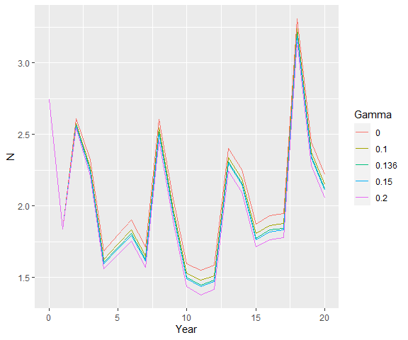

```r
library(ggplot2)
library(dplyr)
ggplot(df %>% mutate(Gamma=factor(Gamma)),aes(x=Year,y=N,colour=Gamma))+geom_line()
```

Generate 101 runs and bind them into one large dataframe. The runs are performed in parallel with the `furrr` library

```r
plan(multiprocess)
system.time(df <- future_map_dfr(1:101,sim))
   user  system elapsed
   0.20    0.06    7.91

#saveRDS(df, "Esup96_sim.rds")
```

## Results

```r
#df<-readRDS("Esup96_sim.rds")
```

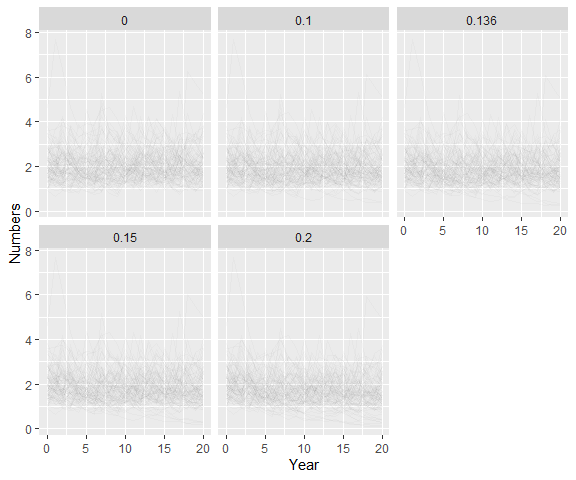

```r
ggplot(df,aes(x=Year,y=N,group=Run))+
  geom_line(colour=rgb(0,0,0,0.02))+
  facet_wrap(~Gamma) + labs(y="Numbers")
```

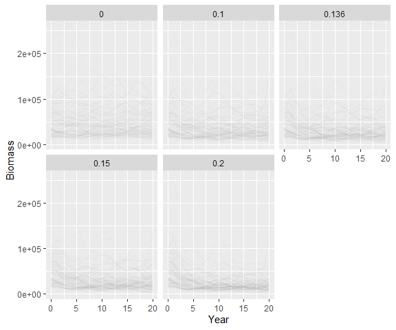

```r
ggplot(df,aes(x=Year,y=B,group=Run))+
  geom_line(colour=rgb(0,0,0,0.02))+
  facet_wrap(~Gamma) + labs(y="Biomass")
```

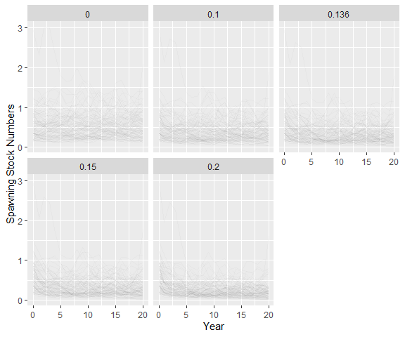

```r
ggplot(df,aes(x=Year,y=SSN,group=Run))+
  geom_line(colour=rgb(0,0,0,0.02))+
  facet_wrap(~Gamma) + labs(y="Spawning Stock Numbers")
```

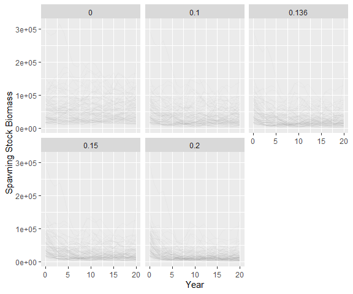

```r
ggplot(df,aes(x=Year,y=SSB,group=Run))+
  geom_line(colour=rgb(0,0,0,0.02))+
  facet_wrap(~Gamma) + labs(y="Spawning Stock Biomass")
```

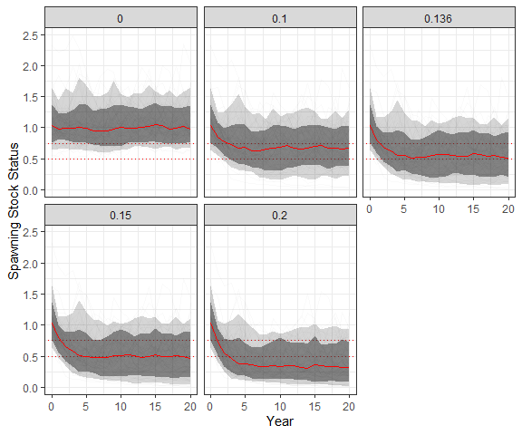

```r
ssbstat<-df %>% group_by(Gamma, Year) %>% summarise(Med=median(SSB.Status), upr=quantile(SSB.Status, 0.975),lwr=quantile(SSB.Status, 0.025),q60=quantile(SSB.Status, 0.1),q40=quantile(SSB.Status, 0.9))
`summarise()` regrouping output by 'Gamma' (override with `.groups` argument)

ggplot(df, aes(x=Year,y=SSB.Status,group=Run))+
  geom_line(colour=rgb(0,0,0,0.02))+
  geom_hline(yintercept=range(0.5,0.75), col="red", lty=3)+
  geom_ribbon(data=ssbstat, aes(x=Year, ymin=lwr, ymax=upr), inherit.aes = FALSE, alpha=0.2)+
  geom_ribbon(data=ssbstat, aes(x=Year, ymin=q40, ymax=q60), inherit.aes = FALSE, alpha=0.5)+
geom_line(data=ssbstat, aes(x=Year, y=Med), inherit.aes = FALSE, col="red")+
  facet_wrap(~Gamma)+
  theme_bw() + labs(y="Spawning Stock Status")
```

```r
names(df)
 [1] "Run"         "M"           "Year"        "Gamma"       "R"
 [6] "N"           "B"           "B0"          "SSN"         "SSB"
[11] "SSB0"        "SSB.Status"  "Catch"       "F"           "Age.Class.1"
[16] "Age.Class.2" "Age.Class.3" "Age.Class.4" "Age.Class.5" "Age.Class.6"
[21] "Age.Class.7" "Age.Class.8"
df1 <- df %>% filter(Year==0) %>% pivot_longer(cols=tidyselect::starts_with("Age.Class"),  names_prefix = "Age.Class.",names_to="Age",values_to="Na")
```

```r
d2 <- df1 %>% group_by(Gamma,Age) %>% summarize(N=mean(Na))
`summarise()` regrouping output by 'Gamma' (override with `.groups` argument)
xtabs(round(N,4)~Gamma+Age,data=d2)
       Age
Gamma        1      2      3      4      5      6      7      8
  0     0.9591 0.4960 0.2837 0.1319 0.0714 0.0417 0.0221 0.0119
  0.1   0.9591 0.4960 0.2837 0.1319 0.0714 0.0417 0.0221 0.0119
  0.136 0.9591 0.4960 0.2837 0.1319 0.0714 0.0417 0.0221 0.0119
  0.15  0.9591 0.4960 0.2837 0.1319 0.0714 0.0417 0.0221 0.0119
  0.2   0.9591 0.4960 0.2837 0.1319 0.0714 0.0417 0.0221 0.0119
```

```r
df1 <- df %>% filter(Year==15) %>% pivot_longer(starts_with("Age.Class"),names_prefix = "Age.Class.",names_to="Age",values_to="Na")
```

```r
d2 <- df1 %>% group_by(Gamma,Age) %>% summarize(N=mean(Na))
`summarise()` regrouping output by 'Gamma' (override with `.groups` argument)
xtabs(round(N,4)~Gamma+Age,data=d2)
       Age
Gamma        1      2      3      4      5      6      7      8
  0     1.0158 0.5032 0.2760 0.1380 0.0663 0.0389 0.0234 0.0140
  0.1   0.9924 0.4950 0.2662 0.1098 0.0407 0.0206 0.0097 0.0052
  0.136 0.9720 0.4873 0.2584 0.0933 0.0295 0.0145 0.0058 0.0030
  0.15  0.9517 0.4780 0.2520 0.0854 0.0251 0.0122 0.0047 0.0023
  0.2   0.9057 0.4475 0.2347 0.0624 0.0142 0.0060 0.0020 0.0008
```

We can use the dplyr function to calculate the depletion probability and the escapement for each Gamma tested.

```r
df %>% group_by(Gamma,Run) %>% summarize(Dep=min(SSB/SSB0)) %>% summarize(Pr=mean(Dep < 0.2))
`summarise()` regrouping output by 'Gamma' (override with `.groups` argument)
`summarise()` ungrouping output (override with `.groups` argument)
# A tibble: 5 x 2
  Gamma     Pr
  <dbl>  <dbl>
1 0     0
2 0.1   0.0891
3 0.136 0.287
4 0.15  0.366
5 0.2   0.634

grymesc<- df %>%  group_by(Gamma) %>% filter(Year %in% max(Year)) %>% summarise(Med=median(SSB/SSB0))
`summarise()` ungrouping output (override with `.groups` argument)

grymtar<- grymesc %>% filter(Gamma==0) %>% mutate(Target=Med*0.75)

grymesc$Target<-grymtar$Target

grymesc
# A tibble: 5 x 3
  Gamma   Med Target
  <dbl> <dbl>  <dbl>
1 0     0.982  0.737
2 0.1   0.676  0.737
3 0.136 0.516  0.737
4 0.15  0.468  0.737
5 0.2   0.313  0.737
```

## References

Constable, AJ, and WK de la Mare. 1996. “A Generalised Model for Evaluating Yield and the Long-Term Status of Fish Stocks Under Conditions of Uncertainty.” *CCAMLR Science* 3: 31–54.